# Determinants of Debt Among Young Adults in the UK

## 1. Introduction

This analysis examines what factors affect the debt of 25-year-olds using data from the Next Steps study, an England-based longitudinal project tracking approximately 16,000 young people across eight waves from 2004. During Wave 1, the participants were aged 13/14, and age 25 during Wave 8. The study documented their education, employment, family, and finances. This project employs multiple linear regression to identify different factors across the years that have impacted the debt in Wave 8. Understanding the factors that affect debt could contribute to improving financial education policy for young adults.

## 2. Data and Methods

### 2.1 Data Loading and Cleaning

The original dataset contains 5,792 observations. After removing missing and negative values for the debt variable (W8QDEB2 — amount in £), the sample size was 2,878. The debt distribution is heavily right-skewed, with most respondents reporting lower levels of debt while only a handful of people have large amounts.

```r
d <- read.csv("data.csv")
```

```r
summary(d$W8QDEB2)
```

```
##    Min. 1st Qu.  Median    Mean 3rd Qu.    Max.
##      -9      -1      -1    5252    3000  650000
```

```r
# Remove NAs and filter for non-negative values
debt <- d$W8QDEB2[!is.na(d$W8QDEB2) & d$W8QDEB2 >= 0]
summary(debt)
```

```
##    Min. 1st Qu.  Median    Mean 3rd Qu.    Max.
##       0     900    3000   10572   10000  650000
```

```r
length(debt)
```

```
## [1] 2878
```

### 2.2 Variable Selection

I chose 7 independent variables for my model:

- **W8DMARSTAT** (marital status): influences financial decisions
- **W8DACTIVITYC** (current activity): affects the likelihood of taking on debt and ability to service debt
- **W8CMSEX** (gender): analyses gender differences in debt behaviour
- **W8TENURE** (housing tenure): represents major financial commitments
- **W1nssecfam** (NS-SEC classification of family, Wave 1): captures patterns of advantage/disadvantage
- **W1ethgrpYP** (ethnic group, Wave 1): explores cultural differences
- **W6DebtattYP** (attitude towards debt, Wave 6): examines whether earlier attitudes predict later behaviour

All variables except W6DebtattYP have nominal values and were factored and relevelled after filtering values ≥ 0.

```r
invalid_counts <- data.frame(
  Variable = c("Marital Status", "Employment", "Gender", "Tenure",
                "NS-SEC Class", "Ethnic Group", "Debt Attitude"),
  Invalid_Values = c(
    sum(d$W8DMARSTAT < 0),
    sum(d$W8DACTIVITYC < 0),
    sum(d$W8CMSEX < 0),
    sum(d$W8TENURE < 0),
    sum(d$W1nssecfam < 0),
    sum(d$W1ethgrpYP < 0),
    sum(d$W6DebtattYP < 0)
  )
)
invalid_counts
```

```
##         Variable Invalid_Values
## 1 Marital Status             13
## 2     Employment             17
## 3         Gender              0
## 4         Tenure             27
## 5   NS-SEC Class            555
## 6   Ethnic Group              8
## 7  Debt Attitude              0
```

### 2.3 Creating the Final Sample

```r
debt_valid <- d[d$W8QDEB2 >= 0, ]
n_valid_debt <- nrow(debt_valid)

reg_data <- d[d$W8QDEB2 >= 0 &
              d$W8DMARSTAT >= 0 &
              d$W8DACTIVITYC >= 0 &
              d$W8CMSEX >= 0 &
              d$W8TENURE >= 0 &
              d$W1nssecfam >= 0 &
              d$W1ethgrpYP >= 0 &
              d$W6DebtattYP >= 0, ]

n_sample <- nrow(reg_data)

cat("Valid debt observations:", n_valid_debt, "\n")
```

```
## Valid debt observations: 2878
```

```r
cat("Final analysis sample:", n_sample, "\n")
```

```
## Final analysis sample: 2613
```

```r
cat("Percentage retained:", round(n_sample / n_valid_debt * 100, 1), "%\n")
```

```
## Percentage retained: 90.8 %
```

### 2.4 Recoding Variables as Factors

```r
# Group activity codes into meaningful employment categories (per LSYPE codebook)
reg_data$employment <- NA
reg_data$employment[reg_data$W8DACTIVITYC %in% c(1, 2)] <- "Employed"
reg_data$employment[reg_data$W8DACTIVITYC %in% c(5, 6, 7)] <- "Education/Training"
reg_data$employment[reg_data$W8DACTIVITYC %in% c(3, 4)] <- "Not working"
reg_data$employment[reg_data$W8DACTIVITYC == 8] <- "Sick/Disabled"
reg_data$employment[reg_data$W8DACTIVITYC == 9] <- "Caring"

reg_data$employment <- factor(reg_data$employment)
reg_data$employment <- relevel(reg_data$employment, ref = "Employed")
```

```r
reg_data$gender <- factor(reg_data$W8CMSEX,
                          levels = c(1, 2),
                          labels = c("Male", "Female"))

reg_data$tenure <- NA
reg_data$tenure[reg_data$W8TENURE == 1] <- "Own - Outright"
reg_data$tenure[reg_data$W8TENURE == 2] <- "Own - Mort or Loan"
reg_data$tenure[reg_data$W8TENURE == 3] <- "Part rent/mortgage"
reg_data$tenure[reg_data$W8TENURE == 4] <- "Rent"
reg_data$tenure[reg_data$W8TENURE == 5] <- "Rent Free (relatives/friends)"
reg_data$tenure[reg_data$W8TENURE %in% c(6, 7)] <- "Other"

reg_data$tenure <- factor(reg_data$tenure)
reg_data$tenure <- relevel(reg_data$tenure, ref = "Own - Outright")
```

```r
reg_data$marital <- NA
reg_data$marital[reg_data$W8DMARSTAT == 1] <- "Single"
reg_data$marital[reg_data$W8DMARSTAT == 2] <- "Married"
reg_data$marital[reg_data$W8DMARSTAT == 3] <- "Separated but legally married"
reg_data$marital[reg_data$W8DMARSTAT %in% c(4, 5)] <- "Previously Married"

reg_data$marital <- factor(reg_data$marital)
reg_data$marital <- relevel(reg_data$marital, ref = "Single")
```

```r
reg_data$ns_sec <- NA
reg_data$ns_sec[reg_data$W1nssecfam == 1] <- "Higher managerial"
reg_data$ns_sec[reg_data$W1nssecfam == 2] <- "Lower managerial"
reg_data$ns_sec[reg_data$W1nssecfam == 3] <- "Intermediate"
reg_data$ns_sec[reg_data$W1nssecfam == 4] <- "Small employers"
reg_data$ns_sec[reg_data$W1nssecfam == 5] <- "Lower supervisory"
reg_data$ns_sec[reg_data$W1nssecfam == 6] <- "Semi-routine"
reg_data$ns_sec[reg_data$W1nssecfam == 7] <- "Routine"
reg_data$ns_sec[reg_data$W1nssecfam == 8] <- "Unemployed"

reg_data$ns_sec <- factor(reg_data$ns_sec)
reg_data$ns_sec <- relevel(reg_data$ns_sec, ref = "Higher managerial")
```

```r
reg_data$ethnicity <- NA
reg_data$ethnicity[reg_data$W1ethgrpYP == 1] <- "White"
reg_data$ethnicity[reg_data$W1ethgrpYP == 2] <- "Mixed"
reg_data$ethnicity[reg_data$W1ethgrpYP == 3] <- "Indian"
reg_data$ethnicity[reg_data$W1ethgrpYP == 4] <- "Pakistani"
reg_data$ethnicity[reg_data$W1ethgrpYP == 5] <- "Bangladeshi"
reg_data$ethnicity[reg_data$W1ethgrpYP %in% c(6, 7)] <- "Black"
reg_data$ethnicity[reg_data$W1ethgrpYP == 8] <- "Other"

reg_data$ethnicity <- factor(reg_data$ethnicity)
reg_data$ethnicity <- relevel(reg_data$ethnicity, ref = "White")
```

## 3. Descriptive Statistics

The cleaned dataset has a debt mean of £10,601, and ranges from £0 to £650,000. Only 3.29% of people have zero debt. The sample was 85.3% single, 86.5% employed, 42.4% male, 3% outright homeowners, 16% from higher managerial family backgrounds, and 78.76% white ethnicity.

```r
summary(reg_data$W8QDEB2)
```

```
##    Min. 1st Qu.  Median    Mean 3rd Qu.    Max.
##       0     850    3000   10601   10000  650000
```

```r
cat("Zero debt:", round(sum(reg_data$W8QDEB2 == 0) / n_sample * 100, 2), "%\n")
```

```
## Zero debt: 3.29 %
```

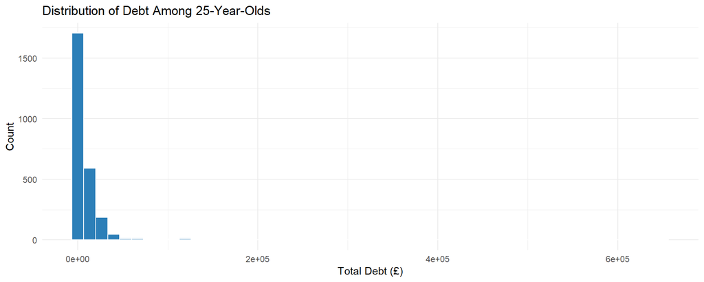

```r
ggplot(reg_data, aes(x = W8QDEB2)) +
  geom_histogram(bins = 50, fill = "#2c7fb8", color = "white") +
  labs(title = "Distribution of Debt Among 25-Year-Olds",
       x = "Total Debt (£)", y = "Count") +
  theme_minimal()
```

```r
cat("Single:", round(sum(reg_data$marital == "Single", na.rm = TRUE) / n_sample * 100, 1), "%\n")
```

```
## Single: 85.3 %
```

```r
cat("Employed:", round(sum(reg_data$employment == "Employed", na.rm = TRUE) / n_sample * 100, 1), "%\n")
```

```
## Employed: 86.5 %
```

```r
cat("Male:", round(sum(reg_data$gender == "Male", na.rm = TRUE) / n_sample * 100, 1), "%\n")
```

```
## Male: 42.4 %
```

```r
cat("Own outright:", round(sum(reg_data$tenure == "Own - Outright", na.rm = TRUE) / n_sample * 100, 1), "%\n")
```

```
## Own outright: 3.1 %
```

```r
cat("Higher managerial:", round(sum(reg_data$ns_sec == "Higher managerial", na.rm = TRUE) / n_sample * 100, 1), "%\n")
```

```
## Higher managerial: 16 %
```

```r
cat("White:", round(sum(reg_data$ethnicity == "White", na.rm = TRUE) / n_sample * 100, 1), "%\n")
```

```
## White: 78.8 %
```

## 4. Regression Results

### 4.1 Original Model

```r
model2 <- lm(W8QDEB2 ~ gender + marital + employment + tenure + ns_sec + ethnicity + W6DebtattYP, data = reg_data)
summary(model2)
```

```
##
## Call:
## lm(formula = W8QDEB2 ~ gender + marital + employment + tenure +
##     ns_sec + ethnicity + W6DebtattYP, data = reg_data)
##
## Residuals:
##    Min     1Q Median     3Q    Max
## -32948  -9595  -3759   1869 626093
##
## Coefficients:
##                                      Estimate Std. Error t value Pr(>|t|)
## (Intercept)                            6568.6     4239.0   1.550  0.12137
## genderFemale                          -3147.8     1150.4  -2.736  0.00626 **
## maritalMarried                         1340.3     1746.5   0.767  0.44293
## maritalPreviously Married              -241.0     7152.4  -0.034  0.97313
## maritalSeparated but legally married  -2207.8     7934.0  -0.278  0.78083
## employmentCaring                       -853.1     2975.4  -0.287  0.77435
## employmentEducation/Training           5919.1     2674.5   2.213  0.02697 *
## employmentNot working                 -2093.7     2930.9  -0.714  0.47506
## employmentSick/Disabled               -1667.2     6135.8  -0.272  0.78586
## tenureOther                            1253.9     3457.3   0.363  0.71688
## tenureOwn - Mort or Loan              14568.6     3458.2   4.213 2.61e-05 ***
## tenurePart rent/mortgage               4090.2     5674.6   0.721  0.47110
## tenureRent                            -1651.1     3330.0  -0.496  0.62005
## tenureRent Free (relatives/friends)     747.3     3495.0   0.214  0.83071
## ns_secIntermediate                    -3678.8     2343.2  -1.570  0.11654
## ns_secLower managerial                -3621.3     1742.8  -2.078  0.03782 *
## ns_secLower supervisory               -6017.6     2213.8  -2.718  0.00661 **
## ns_secRoutine                         -4445.2     2288.7  -1.942  0.05221 .
## ns_secSemi-routine                    -7820.6     2236.9  -3.496  0.00048 ***
## ns_secSmall employers                  -630.9     2143.7  -0.294  0.76854
## ns_secUnemployed                      -3964.2     3517.9  -1.127  0.25990
## ethnicityBangladeshi                  -1388.9     3643.1  -0.381  0.70304
## ethnicityBlack                        -3145.7     2775.9  -1.133  0.25723
## ethnicityIndian                        4189.8     2641.5   1.586  0.11283
## ethnicityMixed                         4465.6     2754.3   1.621  0.10507
## ethnicityOther                        -1217.8     3990.6  -0.305  0.76026
## ethnicityPakistani                      581.7     3627.5   0.160  0.87261
## W6DebtattYP                             486.9      171.7   2.836  0.00460 **
## ---
## Signif. codes:  0 '***' 0.001 '**' 0.01 '*' 0.05 '.' 0.1 ' ' 1
##
## Residual standard error: 28330 on 2576 degrees of freedom
##   (9 observations deleted due to missingness)
## Multiple R-squared:  0.06705,    Adjusted R-squared:  0.05727
## F-statistic: 6.856 on 27 and 2576 DF,  p-value: < 2.2e-16
```

### 4.2 Log-Transformed Model

```r
reg_data$log_debt <- log(reg_data$W8QDEB2 + 1)
model3 <- lm(log_debt ~ gender + marital + employment + tenure + ns_sec + ethnicity + W6DebtattYP, data = reg_data)
summary(model3)
```

```
##
## Call:
## lm(formula = log_debt ~ gender + marital + employment + tenure +
##     ns_sec + ethnicity + W6DebtattYP, data = reg_data)
##
## Residuals:
##     Min      1Q  Median      3Q     Max
## -8.8565 -1.0279  0.3416  1.3512  5.3496
##
## Coefficients:
##                                        Estimate Std. Error t value Pr(>|t|)
## (Intercept)                           6.8829576  0.3221376  21.367  < 2e-16 ***
## genderFemale                         -0.1009018  0.0874209  -1.154  0.24852
## maritalMarried                        0.2779419  0.1327262   2.094  0.03635 *
## maritalPreviously Married             0.3097677  0.5435376   0.570  0.56879
## maritalSeparated but legally married  0.2707028  0.6029295   0.449  0.65348
## employmentCaring                     -0.2506903  0.2261109  -1.109  0.26766
## employmentEducation/Training          0.0396035  0.2032465   0.195  0.84552
## employmentNot working                -0.6131260  0.2227270  -2.753  0.00595 **
## employmentSick/Disabled              -1.0342809  0.4662829  -2.218  0.02663 *
## tenureOther                           0.4710113  0.2627329   1.793  0.07313 .
## tenureOwn - Mort or Loan              1.0354517  0.2628012   3.940 8.36e-05 ***
## tenurePart rent/mortgage              0.4631708  0.4312306   1.074  0.28289
## tenureRent                            0.2356809  0.2530561   0.931  0.35177
## tenureRent Free (relatives/friends)   0.1683006  0.2655995   0.634  0.52636
## ns_secIntermediate                    0.1268049  0.1780661   0.712  0.47645
## ns_secLower managerial               -0.0007494  0.1324428  -0.006  0.99549
## ns_secLower supervisory               0.0224169  0.1682318   0.133  0.89401
## ns_secRoutine                        -0.0752355  0.1739233  -0.433  0.66536
## ns_secSemi-routine                   -0.1291086  0.1699892  -0.760  0.44762
## ns_secSmall employers                 0.3701933  0.1629079   2.272  0.02314 *
## ns_secUnemployed                      0.0315632  0.2673363   0.118  0.90602
## ethnicityBangladeshi                 -0.4430018  0.2768494  -1.600  0.10969
## ethnicityBlack                       -0.2586443  0.2109472  -1.226  0.22027
## ethnicityIndian                      -0.2259029  0.2007338  -1.125  0.26053
## ethnicityMixed                       -0.2787872  0.2093060  -1.332  0.18299
## ethnicityOther                       -0.0177247  0.3032578  -0.058  0.95340
## ethnicityPakistani                   -0.8742144  0.2756685  -3.171  0.00154 **
## W6DebtattYP                           0.0423225  0.0130479   3.244  0.00120 **
## ---
## Signif. codes:  0 '***' 0.001 '**' 0.01 '*' 0.05 '.' 0.1 ' ' 1
##
## Residual standard error: 2.153 on 2576 degrees of freedom
##   (9 observations deleted due to missingness)
## Multiple R-squared:  0.05128,    Adjusted R-squared:  0.04133
## F-statistic: 5.156 on 27 and 2576 DF,  p-value: < 2.2e-16
```

### 4.3 Model Comparison

```r
cat("Original model — Adj. R²:", round(summary(model2)$adj.r.squared, 4), "\n")
```

```
## Original model — Adj. R²: 0.0573
```

```r
cat("Log model — Adj. R²:", round(summary(model3)$adj.r.squared, 4), "\n")
```

```
## Log model — Adj. R²: 0.0413
```

```r
cat("Original model AIC:", round(AIC(model2), 1), "\n")
```

```
## Original model AIC: 60809.7
```

```r
cat("Log model AIC:", round(AIC(model3), 1), "\n")
```

```
## Log model AIC: 11412.6
```

While the original model has a slightly higher adjusted R², it severely violates normality and homoscedasticity assumptions (see Section 5). The log-transformed model better satisfies regression assumptions despite explaining slightly less variance. Note: AIC values are not directly comparable across different transformations of the dependent variable.

### 4.4 Coefficient Plot

```
## `height` was translated to `width`.
```

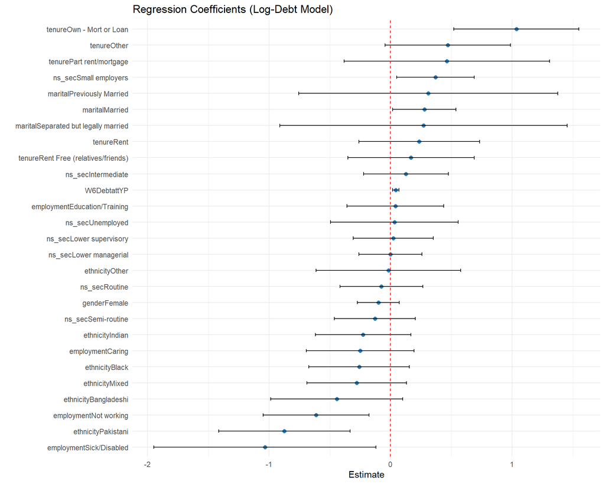

```r
tidy(model3, conf.int = TRUE) %>%
  filter(term != "(Intercept)") %>%
  ggplot(aes(x = estimate, y = reorder(term, estimate))) +
  geom_point(color = "#2c7fb8", size = 2) +
  geom_errorbarh(aes(xmin = conf.low, xmax = conf.high), height = 0.2) +
  geom_vline(xintercept = 0, linetype = "dashed", color = "red") +
  labs(title = "Regression Coefficients (Log-Debt Model)",
       x = "Estimate", y = "") +
  theme_minimal()
```

## 5. Diagnostics

The original model violated regression assumptions. Diagnostic plots revealed heteroscedasticity and non-normal residuals. The log-transformed model addressed these issues, but it has a lower R² value and interpretation in percentage changes is less intuitive.

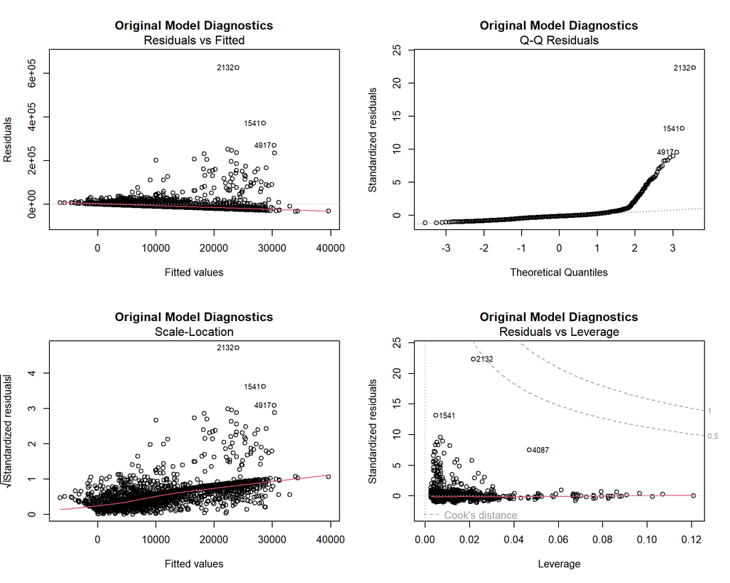

```r
par(mfrow = c(2, 2))
plot(model2, main = "Original Model Diagnostics")
```

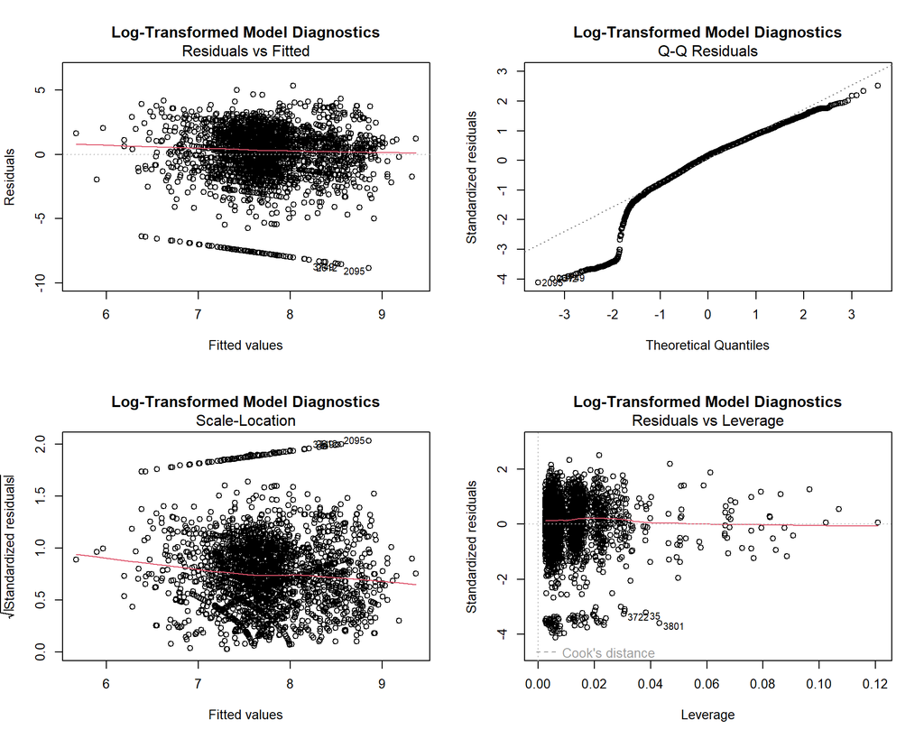

```r
par(mfrow = c(2, 2))
plot(model3, main = "Log-Transformed Model Diagnostics")
```

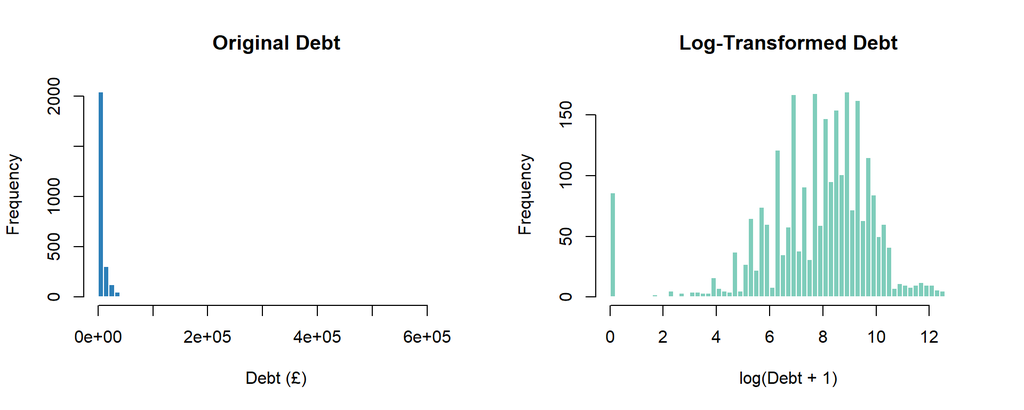

```r
par(mfrow = c(1, 2))

hist(reg_data$W8QDEB2, breaks = 50, col = "#2c7fb8", border = "white",
     main = "Original Debt", xlab = "Debt (£)")

hist(reg_data$log_debt, breaks = 50, col = "#7fcdbb", border = "white",
     main = "Log-Transformed Debt", xlab = "log(Debt + 1)")
```

```r
par(mfrow = c(1, 1))
```

## 6. Interpretation

Debt among 25-year-olds is overwhelmingly affected by housing tenure. Young homeowners with mortgages carry significantly more debt than those who outright own their homes. This makes sense because at age 25, they are probably at the beginning of their mortgage term, leading to other forms of debt like credit cards or other types of loans.

Current activity also matters, exactly as expected. Results show that students and trainees have higher debts — most likely from student loans — while the unemployed and those unable to work have lesser debt, not from preference, but because lenders restrict credit without a stable income.

The gender finding — females carrying less debt — may reflect the 2015 social context where men were more likely to pursue homeownership independently due to traditional gender roles, though research shows this pattern has shifted in recent years with women having more debt than men.

Family socioeconomic classification is an important and interesting predictor of debt. Children from small employer families (typically parents running businesses) carry 45% more debt, likely reflecting entrepreneurial culture where debt is viewed as a business tool, combined with middle-class aspirations requiring borrowing without full parental wealth to avoid loans. On the other hand, children of lower occupational classes like lower managerial/supervisory and routine/semi-routine occupations have lower debts. This could be because lower family income makes it harder to save for deposits, and banks are less willing to lend money without family guarantors. They are also unlikely to have mortgage debt as they probably rent or live with family/friends.

Culture and marital status also affect debt. Ethnically Pakistani respondents have lesser debt, possibly due to South Asian culture of having greater financial support from family or even different religious principles. Marriage increases debt by 32%, likely because couples take on joint financial commitments like mortgages.

## 7. Limitations

Both models explain minimal variance in debt (adjusted R² of 4–6%). Many factors like education, income, and specific loan types could better explain debt but are unmeasured. Additionally, missing data reduces the accuracy and reliability of the model. The model also does not explain causal relationships between debt and other variables. For example, we cannot determine whether employment causes debt or vice versa.

## 8. Conclusion

Debt among 25-year-olds in the Next Steps study is mainly affected by housing tenure and varies with current activity and their family’s socio-economic classifications. Respondents who bought homes with mortgages or loans have significantly higher debt than those who outright own homes. Students have higher debts likely due to student loans, while the unemployed have lesser debts because they don’t have access to loans without a stable source of income. The low explanatory power suggests debt is influenced by many unmeasured individual and contextual factors.